# 09_PINN_Labs_textbook

and the factor of ten is the first non-unit weight in this notebook. It is deliberate and the reason is structural rather than empirical. In the forward problems of Sections 4 to 6, every term of the loss was pushing towards the same unique answer, so the weighting affected only the rate of convergence. Here the equation and boundary terms have a whole family of solutions available to them, one for each pair $(\rho,\mu)$, and the data term is the *only* term that distinguishes among them. Under-weighting it would let the network settle into some equation-satisfying flow with wrong properties and a small total loss. The data term is carrying the entire identification, and seventeen points against nearly twenty thousand collocation points would otherwise be a whisper against a shout.

A single optimizer step updates the network weights, the density, and the viscosity together, which is Section 3 in **Physics-informed Neural Networks (PINN)**'s central claim reduced to one line of code.

**What is identifiable, and why the pressure observations matter**

Before reading the answer, here is an argument worth following, because it decides whether this problem can be solved at all.

Suppose $(u, v, p, \rho, \mu)$ satisfies all three equations. Consider the scaled candidate $(u, v, cp, c\rho, c\mu)$ for any constant $c > 0$: the velocities are untouched, the pressure and both parameters are multiplied by $c$. Substituting into the first momentum equation, every term acquires exactly one factor of $c$, since the convective term carries $\rho$, the pressure term carries $p$, and the viscous term carries $\mu$. The residual is therefore multiplied by $c$ and remains zero. Continuity is untouched because it involves only the velocities. The boundary conditions are untouched as well: the inlet condition constrains $u$, and the outlet condition sets $p=0$, which is preserved by scaling. So the scaled candidate satisfies the physics exactly as well as the original.

The consequence is that the equations and boundary conditions alone determine only the *ratio* $\rho/\mu$, which is to say the Reynolds number, and not the individual values. If the sensors reported velocities only, the two parameters would be individually unidentifiable, the traces would wander along the one-parameter family, and no amount of training would fix it. It is the observed *pressure* that breaks the degeneracy, because scaling $p$ by $c$ changes the data residual. Note that this is a property of the problem, not of the method: a classical identification from velocity data alone would face exactly the same obstruction. Recognizing such degeneracies before running anything is a large part of the practical skill in inverse problems.

```python
Y_domain = torch.tensor(Y_domain, dtype = torch.float32, requires_grad = True).to(device)
Y_wall = torch.tensor(Y_wall, dtype = torch.float32).to(device)
Y_inlet = torch.tensor(Y_inlet, dtype = torch.float32).to(device)
Y_outlet = torch.tensor(Y_outlet, dtype = torch.float32).to(device)
Y_obs = torch.tensor(Y_obs, dtype = torch.float32).to(device)
gt_obs = torch.tensor(gt_obs, dtype = torch.float32).to(device)

epoch = 0
loss_list = []
rho_list, vis_list = [], []
```

```
EPOCH :  50000/ 50000 | Loss_PDE : 0.0017 | Loss_BC : 0.0070 | Loss_DATA : 0.0000 | RHO : 0.9879 | VIS : 0.0099
```

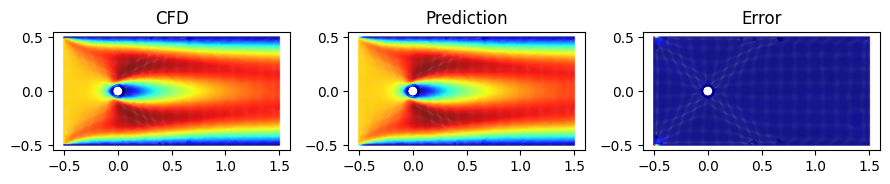

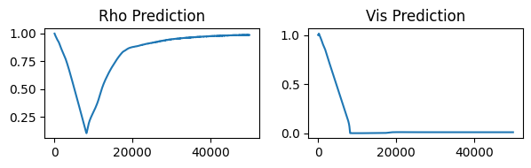

```python
# while epoch < 50001:
#     ## PDE loss
#     PDE_v1, PDE_v2, PDE_cont = PDE(model, Y_domain)
#     loss_pde = torch.mean(PDE_v1**2) + torch.mean(PDE_v2**2) + torch.mean(PDE_cont**2)

#     ## BC loss
#     v1_wall, v2_wall = BC_wall(model, Y_wall)
#     v1_inlet, v2_inlet = BC_inlet(model, Y_inlet)
#     v2_outlet, p_outlet = BC_outlet(model, Y_outlet)

#     loss_bc = (torch.mean(v1_wall**2) + torch.mean(v2_wall**2)
#                + torch.mean(v1_inlet**2) + torch.mean(v2_inlet**2)
#                + torch.mean(v2_outlet**2) + torch.mean(p_outlet**2))

#     ## Data loss
#     u_obs, v_obs, p_obs = model(Y_obs)
#     loss_data = (torch.mean((u_obs - gt_obs[:, 0:1])**2)
#                  + torch.mean((v_obs - gt_obs[:, 1:2])**2)
#                  + torch.mean((p_obs - gt_obs[:, 2:3])**2))

#     loss = loss_pde + loss_bc + 10 * loss_data

#     optimizer.zero_grad()
#     loss.backward()
#     optimizer.step()

#     loss_list.append(loss.item())
#     rho_list.append(rho.item())
#     vis_list.append(vis.item())

#     if epoch % 500 == 0:
#         print('EPOCH : %6d/%6d | Loss_PDE : %5.4f | Loss_BC : %5.4f | Loss_DATA : %5.4f | RHO : %.4f | VIS : %.4f' \
#                 %(epoch, 50000, loss_pde.item(), loss_bc.item(), loss_data.item(), rho.item(), vis.item()))
#         PLOT(model, Y_domain, rho_list, vis_list)

#     epoch += 1
```

```python
# # Save the model and the parameter histories
# torch.save(model, 'lab3_model.pt')
# np.save('rho_list.npy', np.array(rho_list))
# np.save('vis_list.npy', np.array(vis_list))

# print("Model saved as lab3_model.pt")
# print("Rho list saved as rho_list.npy")
# print("Viscosity list saved as vis_list.npy")
```

```
Model saved as lab3_model.pt
Rho list saved as rho_list.npy
Viscosity list saved as vis_list.npy
```

**Result**

The trained model and the two parameter traces are provided so that the result can be inspected without a fifty-thousand-iteration run.

- [lab3_model.pt](https://drive.google.com/file/d/1ebNl9iZphjsvmWw_vCSFwnA8forR8woj/view?usp=drive_link)
- [rho_list](https://drive.google.com/file/d/1KWDXGCsooxXvH5rmoQWRS_143eGspTrD/view?usp=drive_link)
- [vis_list](https://drive.google.com/file/d/18CIt0fsRLbaQjQQrFzXq2i3M8sfwIyz5/view?usp=drive_link)

```python
!gdown 1ebNl9iZphjsvmWw_vCSFwnA8forR8woj -O /content/lab3_model.pt
!gdown 1KWDXGCsooxXvH5rmoQWRS_143eGspTrD -O /content/rho_list.npy
!gdown 18CIt0fsRLbaQjQQrFzXq2i3M8sfwIyz5 -O /content/vis_list.npy
```

```
Downloading...
From: https://drive.google.com/uc?id=1ebNl9iZphjsvmWw_vCSFwnA8forR8woj
To: /content/lab3_model.pt
100% 802k/802k [00:00<00:00, 132MB/s]
Downloading...
From: https://drive.google.com/uc?id=1KWDXGCsooxXvH5rmoQWRS_143eGspTrD
To: /content/rho_list.npy
100% 400k/400k [00:00<00:00, 117MB/s]
Downloading...
From: https://drive.google.com/uc?id=18CIt0fsRLbaQjQQrFzXq2i3M8sfwIyz5
To: /content/vis_list.npy
100% 400k/400k [00:00<00:00, 129MB/s]
```

```
Predicted RHO: 0.9945, Predicted VIS: 0.0099
```

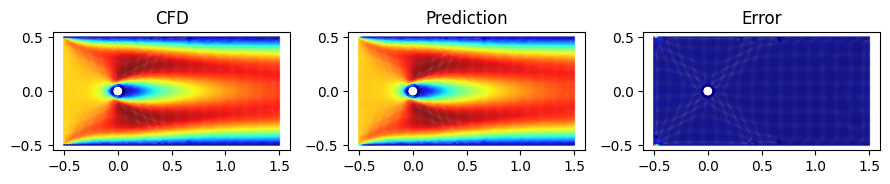

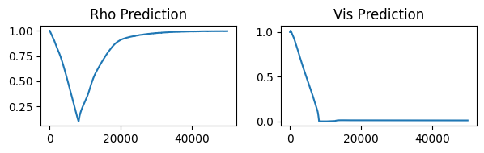

```python
# Load the estimated parameters and the pre-trained model
rho_list = np.load('/content/rho_list.npy').tolist()
vis_list = np.load('/content/vis_list.npy').tolist()
model = torch.load('/content/lab3_model.pt', map_location = device, weights_only = False)

print(f'Predicted RHO: {rho_list[-1]:.4f}, Predicted VIS: {vis_list[-1]:.4f}\n')

Y_domain_tensor = torch.tensor(np.load('/content/lab3_XY_domain.npy'), dtype = torch.float32).to(device)
PLOT(model, Y_domain_tensor, rho_list, vis_list)
```

## 4.3. What the Lab Showed

Against the true values $\rho = 1$ and $\mu = 0.01$, both parameters are recovered to within about one percent, the viscosity having travelled two orders of magnitude down from its initial value. Both estimates were obtained from seventeen measurements, fewer than one domain point in a thousand, together with the knowledge that the flow obeys the Navier-Stokes equations.

That result deserves a moment's reflection rather than a nod. The network was never told what a density is. It was given a functional form containing two unknown numbers, a set of coordinates, and seventeen readings, and it recovered both numbers by gradient descent, at the same time and in the same loop as it recovered the flow field. The estimated field, shown in the first row of panels against the CFD reference and the pointwise error, is a by-product; in an identification problem it is the two numbers that were wanted.

Read the parameter traces as well as the printed values. Both should have flattened well before the end of the run, and it is the flatness rather than the final value that tells you the estimate is trustworthy. A trace that is still descending at the last iteration reports where the optimizer happened to be when the loop ended, which is not an estimate of anything.

One caveat completes the picture. The sensor readings here were taken from the CFD solution without added noise, so the data is exactly consistent with the equations, and the estimates are correspondingly clean. With noisy measurements the identified parameters would carry uncertainty, and quantifying that uncertainty, rather than reporting a single point estimate, is where serious inverse-problem practice begins. The framework of this section gives a point estimate and no error bar.

# 5. Heated Plate with an Unknown Edge

**Overview**

Another common type of inverse problem involves unknown boundary conditions. It arises constantly in practice: a component is instrumented on its accessible faces, and the condition on the inaccessible one, buried, submerged, or in contact with something unmeasured, is exactly what one wants to know. Here the setting is two-dimensional steady heat conduction on a square, with three of the four edges at known temperatures and the fourth entirely unknown. By leveraging a PINN we can infer the missing boundary condition from observed temperature data while remaining consistent with the governing heat equation.

This section is arranged as a controlled experiment in three stages, and the arrangement is the point. Section 5.2 solves the problem with physics alone and shows the failure. Section 5.3 adds nine thermometers. Section 5.4 adds one further piece of knowledge, namely that the unknown boundary temperature is uniform along the edge, without saying what value it takes. Section 5.5 compares the three recovered boundary profiles against the truth on a single plot. Each stage adds information rather than tuning, and the improvements are attributable to the information added.

## 5.1. The Problem

The setting is steady two-dimensional heat conduction on a square plate. Three edges are held at known temperatures; the fourth is inaccessible, and its temperature profile is what we want.

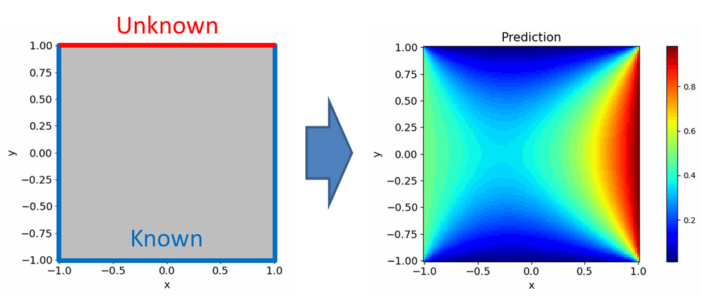

**Problem properties**

$$ \kappa = 1 $$

**Governing equation and boundary conditions**

$$ \kappa \left(\frac{\partial^2 T}{\partial x^2} + \frac{\partial^2 T}{\partial y^2} \right) = 0$$

This is Laplace's equation for the temperature, the steady-state form of the heat equation. It follows from conservation of energy together with Fourier's law: the heat flux is $\mathbf{q} = -\kappa \nabla T$, and in the steady state with no internal generation the flux is divergence-free, so $\nabla\cdot(\kappa\nabla T)=0$, which for constant $\kappa$ reduces to $\nabla^2 T = 0$. PINN: Limitations and Overcoming Strategies takes up the case where $\kappa$ is *not* constant, and the distinction between the two forms of the equation matters a great deal there.

Since $\kappa$ is a positive constant, multiplying the Laplacian by it changes nothing about which fields satisfy the equation. It is retained here because the code writes it, and because in a two-material problem the corresponding factor is not constant.

The domain is the square $[-1,1]\times[-1,1]$ and three of its edges carry prescribed temperatures.

- Left boundary condition ($x=-1$):

$$T|_{x = -1} = 0.5$$

- Right boundary condition ($x=1$):

$$T|_{x = 1} = 1$$

- Bottom boundary condition ($y = -1$):

$$T|_{y = -1} = 0$$

- The top boundary condition $(y = 1)$ is unknown.

$$T|_{y = 1} = \; ?$$

**Why this is a genuinely different situation**

Laplace's equation on a bounded domain is well posed when a condition is given on the entire boundary, and it is not well posed when part of the boundary is left free. The consequence is not that the answer is slightly less accurate. It is that there is no unique answer: any smooth profile assigned to the top edge produces a different harmonic function inside, and all of them satisfy the equation and the three known edges exactly. The solution set is an infinite-dimensional family.

A conventional finite element or finite difference code cannot even be started in this situation, since assembling its system of equations requires a value or a flux at every boundary node. A PINN, by contrast, will run happily: it will minimize a loss that contains no information about the top edge, and it will return one member of the family. Whether that member is the right one is another question, and Section 5.2 answers it.

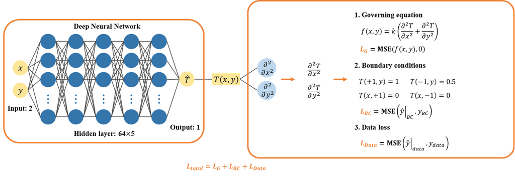

## 5.2. Lab 1: Inverse Problem without Observed Data

**Import Library**

```python
import numpy as np
import torch
import torch.nn as nn
import matplotlib.pyplot as plt

device = torch.device('cuda:0' if torch.cuda.is_available() else 'cpu')
print(device)
```

```
cuda:0
```

**Load the Data**

- [lab4_gt_domain](https://drive.google.com/file/d/1PHr2D76v31bQ58vrw9O1B5yqyJUovaC4/view?usp=sharing)

As in Section 6 in **Physics-informed Neural Networks (PINN)**, this reference plays two roles that should be kept distinct: it supplies the nine sensor readings used for training in Sections 5.3 and 5.4, and it supplies the ground truth against which all three models are judged. Only nine of its ten thousand values ever reach the optimizer.

```python
!gdown 1PHr2D76v31bQ58vrw9O1B5yqyJUovaC4 -O /content/lab4_gt_domain.npy
```

```
Downloading...
From: https://drive.google.com/uc?id=1PHr2D76v31bQ58vrw9O1B5yqyJUovaC4
To: /content/lab4_gt_domain.npy
100% 80.1k/80.1k [00:00<00:00, 47.9MB/s]
```

```python
gt_domain = np.load('/content/lab4_gt_domain.npy')
```

**Define Observation Points**

Assume that nine thermometers are positioned inside the plate. Their readings are the observed data from which the unknown boundary condition will be inferred.

The sensors form a regular $3\times3$ array well inside the domain, none of them close to the unknown top edge, which is realistic: an inaccessible boundary is inaccessible to instrumentation as well.

Nine numbers is a thin diet even compared with the seventeen of Section 4, and the unknown here is not a pair of scalars but an entire function along an edge. That mismatch is why Section 5.3 improves the answer without perfecting it, and why Section 5.4 needs to supply structure rather than more data.

The plot shows the finite difference field with the nine sensor locations marked in red. Read the field before continuing: the right edge is hot at $T=1$, the left edge is at $T=0.5$, the bottom edge is cold at $T=0$, and the top edge is where the interesting question lies.

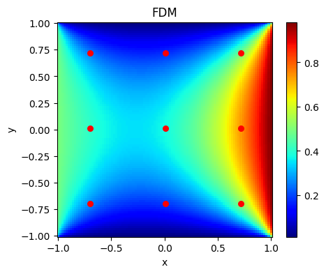

```python
plt.figure(figsize = (5, 4))
x = np.linspace(-1, 1, 100)
y = np.linspace(-1, 1, 100)
x, y = np.meshgrid(x, y)

idx_xs = np.array([15, 50, 85])
idx_ys = np.array([15, 50, 85])

Y_obs = []
gt_obs = []
for idx_x in idx_xs:
    for idx_y in idx_ys:
        Y_obs.append(np.concatenate((x[idx_x, idx_y].reshape(-1, 1),
                                      y[idx_x, idx_y].reshape(-1, 1)), 1)[0, :])
        gt_obs.append(gt_domain[idx_x, idx_y])

Y_obs = np.array(Y_obs)
gt_obs = np.array(gt_obs).reshape(-1, 1)

plt.pcolormesh(x, y, gt_domain, cmap = 'jet')
plt.colorbar()
plt.scatter(Y_obs[:, 0], Y_obs[:, 1], s = 30, c = 'r')
plt.title('FDM')
plt.xlabel('x')
plt.ylabel('y')
plt.axis("square")
plt.show()
```

**Define Collocation Points**

Collocation points fill the square, and each of the four edges is sampled as well. The top edge is included even though no condition is imposed on it in this section; it will be needed in Section 5.4, where the prior knowledge term is evaluated there, and in Section 5.5, where the recovered profile is plotted along it.

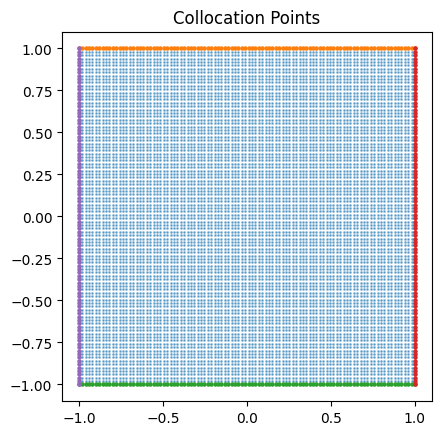

```python
# 'Domain Points'
x = np.linspace(-1, 1, 100)
y = np.linspace(-1, 1, 100)
x, y = np.meshgrid(x, y)
Y_domain = np.concatenate((x.reshape(-1, 1), y.reshape(-1, 1)), 1)

# 'Boundary Conditions'
bc_top_x = np.linspace(-1, 1, 100).reshape(-1, 1)
bc_top_y = np.ones_like(bc_top_x)

bc_bottom_x = np.linspace(-1, 1, 100).reshape(-1, 1)
bc_bottom_y = -1 * np.ones_like(bc_bottom_x)

bc_right_y = np.linspace(-1, 1, 100).reshape(-1, 1)
bc_right_x = np.ones_like(bc_right_y)

bc_left_y = np.linspace(-1, 1, 100).reshape(-1, 1)
bc_left_x = -1 * np.ones_like(bc_left_y)

Y_top = np.concatenate((bc_top_x, bc_top_y), 1)
Y_bottom = np.concatenate((bc_bottom_x, bc_bottom_y), 1)
Y_right = np.concatenate((bc_right_x, bc_right_y), 1)
Y_left = np.concatenate((bc_left_x, bc_left_y), 1)

plt.scatter(Y_domain[:, 0], Y_domain[:, 1], s = 1, alpha = 0.5)
plt.scatter(Y_top[:, 0], Y_top[:, 1], s = 5)
plt.scatter(Y_bottom[:, 0], Y_bottom[:, 1], s = 5)
plt.scatter(Y_right[:, 0], Y_right[:, 1], s = 5)
plt.scatter(Y_left[:, 0], Y_left[:, 1], s = 5)
plt.title('Collocation Points')
plt.axis('scaled')
plt.show()

Y_domain = torch.tensor(Y_domain, dtype = torch.float32, requires_grad = True).to(device)
Y_bottom = torch.tensor(Y_bottom, dtype = torch.float32).to(device)
Y_right = torch.tensor(Y_right, dtype = torch.float32).to(device)
Y_left = torch.tensor(Y_left, dtype = torch.float32).to(device)
Y_top = torch.tensor(Y_top, dtype = torch.float32).to(device)
Y_obs = torch.tensor(Y_obs, dtype = torch.float32).to(device)
gt_obs = torch.tensor(gt_obs, dtype = torch.float32).to(device)
```

**Define PINN Network**

The network is nearly as large as the Navier-Stokes network of Section 4, which is generous for a linear equation in a single field. Since the whole section is a comparison between three training regimes, a fixed and generous architecture is the right choice: it removes capacity from the list of possible explanations for the differences observed.

The plotting helper draws the reference field, the current prediction, and the absolute error on a fixed colour scale, so that the three regimes of Sections 5.2 to 5.4 can be compared on identical terms.

```python
class PINN(nn.Module):
    def __init__(self):
        super(PINN, self).__init__()
        self.net = nn.Sequential(
            nn.Linear(2, 256),
            nn.Tanh(),
            nn.Linear(256, 256),
            nn.Tanh(),
            nn.Linear(256, 256),
            nn.Tanh(),
            nn.Linear(256, 256),
            nn.Tanh(),
            nn.Linear(256, 1)
        )
        for m in self.net:
            if isinstance(m, nn.Linear):
                nn.init.xavier_normal_(m.weight)
                nn.init.zeros_(m.bias)

    def forward(self, x):
        return self.net(x)

model = PINN().to(device)
optimizer = torch.optim.Adam(model.parameters(), lr = 1e-4)
```

```python
from IPython.display import clear_output

def PLOT(model_test, Y_domain):
    pred = model_test(Y_domain).detach().cpu().numpy()
    xy = Y_domain.detach().cpu().numpy()
    gt = gt_domain.reshape(-1, 1)

    plt.figure(figsize = (9, 2.3))
    plt.subplot(1, 3, 1)
    plt.title('CFD')
    plt.scatter(xy[:, 0], xy[:, 1], c = gt, vmin = 0, vmax = 1, s = 1, cmap = 'jet')
    plt.colorbar()
    plt.axis('scaled')

    plt.subplot(1, 3, 2)
    plt.title('Prediction')
    plt.scatter(xy[:, 0], xy[:, 1], c = pred, vmin = 0, vmax = 1, s = 1, cmap = 'jet')
    plt.colorbar()
    plt.axis('scaled')

    plt.subplot(1, 3, 3)
    plt.title('Error')
    plt.scatter(xy[:, 0], xy[:, 1], c = np.abs(pred - gt), vmin = 0, vmax = 0.2, s = 1, cmap = 'jet')
    plt.colorbar()
    plt.axis('scaled')
    plt.tight_layout()
    plt.show()
    clear_output(wait = True)
```

**Define Functions to Compute Physics Loss**

The same helper as before.

```python
def derivative(y, t):
    df = torch.autograd.grad(y, t, grad_outputs = torch.ones_like(y), create_graph = True)[0]
    df_x = df[:, 0:1]
    df_y = df[:, 1:2]
    return df_x, df_y
```

**Define Governing Equation and Three Known Boundary Conditions**

The residual is the Laplacian of the network output, and the three boundary functions compare the network with the prescribed values on the bottom, right and left edges.

There is no function for the top edge. That absence is the entire content of this section, and it is worth pausing on the fact that nothing in the code will complain about it. The loss will be assembled from four terms, will descend, and will produce a field. The missing physics announces itself nowhere except in the answer.

```python
def PDE(model, Y_domain):
    T = model(Y_domain)

    dT_x, dT_y = derivative(T, Y_domain)
    dT_xx, _ = derivative(dT_x, Y_domain)
    _, dT_yy = derivative(dT_y, Y_domain)

    pde = 1 * (dT_xx + dT_yy)
    return pde

def BC_bottom(model, Y_bottom):
    T_bottom = model(Y_bottom)
    return T_bottom

def BC_right(model, Y_right):
    T_right = model(Y_right)
    return T_right - 1

def BC_left(model, Y_left):
    T_left = model(Y_left)
    return T_left - 0.5
```

**Train**

The loss is

$$ \mathcal{L} = \mathcal{L}_{\text{PDE}} + \mathcal{L}_{\text{bottom}} + \mathcal{L}_{\text{right}} + \mathcal{L}_{\text{left}}, $$

with no term for the top edge and no data. This is the pure physics baseline.

```
EPOCH :  20000/ 20000| Loss : 0.0246 | Loss_PDE : 0.0020 | Loss_BC : 0.0226
```

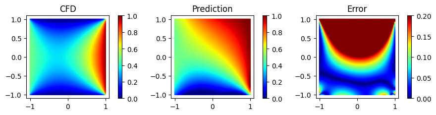

```python
# epochs = 20001

# for epoch in range(epochs):

#     ## PDE loss
#     pde_term = PDE(model, Y_domain)
#     loss_pde = torch.mean(pde_term**2)

#     ## BC loss
#     T_bottom = BC_bottom(model, Y_bottom)
#     T_right = BC_right(model, Y_right)
#     T_left = BC_left(model, Y_left)

#     loss_bc = torch.mean(T_bottom**2) + torch.mean(T_right**2) + torch.mean(T_left**2)

#     loss = loss_pde + loss_bc

#     optimizer.zero_grad()
#     loss.backward()
#     optimizer.step()

#     if epoch % 1000 == 0:
#         print('EPOCH : %6d/%6d| Loss : %5.4f | Loss_PDE : %5.4f | Loss_BC : %5.4f' \
#                 %(epoch, epochs-1, loss.item(), loss_pde.item(), loss_bc.item()))
#         PLOT(model, Y_domain)
```

```python
# import torch
# torch.save(model, 'lab4_wo_data.pt')
# print("Model successfully saved as lab4_wo_data.pt")
```

```
Model successfully saved as lab4_wo_data.pt
```

**Result**

As shown, the prediction deviates significantly from the ground truth due to the absence of one boundary condition, and the reason is the absent condition rather than any failure of training. It is worth being precise about the two contrasting behaviours.

Most conventional computational methods cannot produce any result at all unless every boundary condition is specified, because a missing condition leaves their system of equations singular or under-determined and the solve fails outright. A PINN never assembles such a system. It minimizes a penalty, and a penalty that says nothing about the top edge simply leaves the network free there; the optimizer settles on whichever admissible field its initialization and its trajectory happen to lead it to.

This is directly analogous to an under-determined system of linear equations, which has infinitely many solutions and whose standard algorithms return one particular member of the family, typically the one of smallest norm, without any indication that others exist. A PINN behaves the same way and offers the same false comfort: the loss will look small, because the terms in it really are being satisfied, and the answer will still be wrong.

Load the model parameters

- [lab4_wo_data.pt](https://drive.google.com/file/d/1SuQvz8T2SsKo_5pVLvAMXySqKG9jfxiy/view?usp=sharing)

```python
!gdown 1SuQvz8T2SsKo_5pVLvAMXySqKG9jfxiy -O /content/lab4_wo_data.pt
```

```
Downloading...
From: https://drive.google.com/uc?id=1SuQvz8T2SsKo_5pVLvAMXySqKG9jfxiy
To: /content/lab4_wo_data.pt
100% 800k/800k [00:00<00:00, 145MB/s]
```

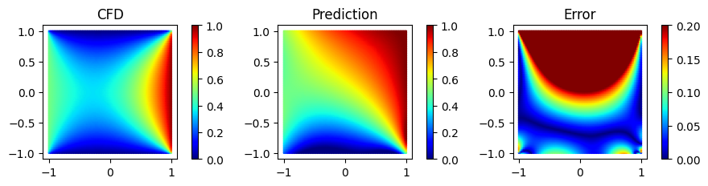

```python
model = torch.load('/content/lab4_wo_data.pt', map_location = device, weights_only = False)
PLOT(model, Y_domain)
```

## 5.3. Lab 2: Inverse Problem with Observed Data

We now incorporate the readings from the nine sensors, giving the PINN more information with which to infer the missing boundary condition.

The analogy with systems of equations carries over exactly. Adding nine observations adds nine conditions on the same unknowns, pushing the problem from under-determined towards over-determined, and an over-determined system is handled by least squares, returning the solution that best satisfies all constraints simultaneously. That is precisely what minimizing a sum of squared residuals does, and it is why the sum-of-squares form of the PINN loss is the right one rather than merely a convenient one.

Nine numbers cannot determine an entire boundary profile, so we should expect improvement rather than resolution. The interesting question, which Section 5.5 answers, is how much of the profile nine interior temperatures can recover.

**Train with data**

The model is rebuilt from scratch and trained with the same settings, so that the comparison is clean. The loss now carries one additional term,

$$ \mathcal{L} = \mathcal{L}_{\text{PDE}} + \mathcal{L}_{\text{BC}} + \mathcal{L}_{\text{data}}, $$

with $\mathcal{L}_{\text{data}}$ the mean squared error between the network's prediction and the nine measured temperatures. Its weight is $1$, in contrast to the $10$ used in Section 4. The difference in circumstances justifies the difference in weight: there the data term was the sole means of identifying two scalars against nineteen thousand collocation points, while here it competes against a merely under-determined physics loss and is not being asked to fix a scale.

```python
model = PINN().to(device)
optimizer = torch.optim.Adam(model.parameters(), lr = 1e-4)
```

```
EPOCH :  20000/ 20000| Loss : 0.0238 | Loss_PDE : 0.0015 | Loss_BC : 0.0204 | Loss_DATA : 0.0019
```

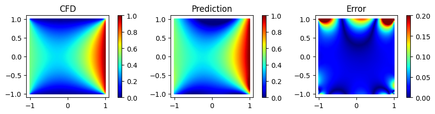

```python
# for epoch in range(epochs):

#     ## PDE loss
#     pde_term = PDE(model, Y_domain)
#     loss_pde = torch.mean(pde_term**2)

#     ## BC loss
#     T_bottom = BC_bottom(model, Y_bottom)
#     T_right = BC_right(model, Y_right)
#     T_left = BC_left(model, Y_left)

#     loss_bc = torch.mean(T_bottom**2) + torch.mean(T_right**2) + torch.mean(T_left**2)

#     ## Data loss
#     T_obs = model(Y_obs)
#     loss_data = torch.mean((T_obs - gt_obs)**2)

#     loss = loss_pde + loss_bc + loss_data

#     optimizer.zero_grad()
#     loss.backward()
#     optimizer.step()

#     if epoch % 1000 == 0:
#         print('EPOCH : %6d/%6d| Loss : %5.4f | Loss_PDE : %5.4f | Loss_BC : %5.4f | Loss_DATA : %5.4f' \
#                 %(epoch, epochs-1, loss.item(), loss_pde.item(), loss_bc.item(), loss_data.item()))
#         PLOT(model, Y_domain)
```

```python
# import torch
# torch.save(model, 'lab4_w_data.pt')
# print("Model successfully saved as lab4_w_data.pt")
```

```
Model successfully saved as lab4_w_data.pt
```

**Result**

The results demonstrate improved predictions, although they still do not perfectly match the ground truth. The obvious remedy is more sensors, and it would work; nine measurements are simply too few to determine a function on an edge. But there is a second kind of remedy available, and it is more interesting because it costs nothing.

Load the model parameters

- [lab4_w_data.pt](https://drive.google.com/file/d/1rhxBpNgUoi0dUNFUCbEZfYL_hjuh3aiB/view?usp=sharing)

```python
!gdown 1rhxBpNgUoi0dUNFUCbEZfYL_hjuh3aiB -O /content/lab4_w_data.pt
```

```
Downloading...
From: https://drive.google.com/uc?id=1rhxBpNgUoi0dUNFUCbEZfYL_hjuh3aiB
To: /content/lab4_w_data.pt
100% 800k/800k [00:00<00:00, 88.2MB/s]
```

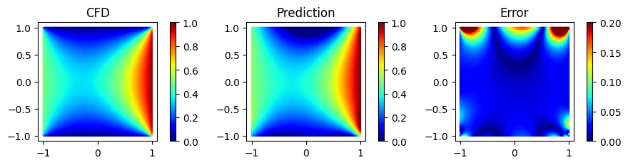

```python
model_w_data = torch.load('/content/lab4_w_data.pt', map_location = device, weights_only = False)
PLOT(model_w_data, Y_domain)
```

## 5.4. Lab 3: Inverse Problem with Observed Data and Prior Knowledge

To make this example more interesting, let us assume that we have prior knowledge that the temperature at the missing boundary is unknown but *constant*. This is a very ordinary kind of engineering knowledge. An edge in contact with a large well-stirred reservoir, or with a boiling liquid, or with a block of high-conductivity metal, is at a uniform temperature whether or not anyone has measured it.

The information is qualitative, and it is not a boundary condition in the usual sense, since it names no value. It is nevertheless enormously informative. The space of possible top-edge profiles collapses from an infinite-dimensional function space to a single real number, and nine sensors are ample to determine one number.

**Expressing "constant but unknown" as a loss**

The implementation is three lines and is the most elegant construction in this notebook. Evaluate the network along the top edge to get $T_{\text{top}}$, compute the mean of those values, and penalize the mean squared deviation of the values from their own mean:

$$ \mathcal{L}_{\text{prior}} = \frac{1}{N}\sum_{i=1}^{N}\left(T_\theta(x_i, 1) - \bar{T}\right)^2, \qquad \bar{T} = \frac{1}{N}\sum_{j=1}^{N} T_\theta(x_j, 1). $$

This is exactly the sample variance of the predicted top-edge temperature. It is zero when and only when the profile is constant, and it says nothing whatever about which constant. The target of the mean squared error is not a fixed number supplied by the modeller but a quantity computed from the network's own output, and because it is computed with ordinary differentiable operations, gradients flow through it: the penalty pushes each edge value towards the current mean while the mean itself is free to drift to wherever the rest of the loss wants it.

The general lesson is worth extracting from the special case. Anything you know about the solution that can be written as a differentiable function of the network output, vanishing when the knowledge is respected, can be added to the loss as a term. Monotonicity, symmetry, non-negativity, a bound, an integral constraint, a known asymptotic slope: these are all expressible in the same way. The PINN loss is not restricted to differential equations. It is a place to put everything you know, which is the theme Embedding Prior Knowledge into Neural Networks develops at length.

**Train again using both data and prior knowledge**

The model is rebuilt once more and trained with

$$ \mathcal{L} = \mathcal{L}_{\text{PDE}} + \mathcal{L}_{\text{BC}} + \mathcal{L}_{\text{data}} + \mathcal{L}_{\text{prior}}, $$

all weights equal to one. Predict the outcome before running it. The physics fixes the field given the boundary, the prior reduces the unknown boundary to a single number, and nine sensors overdetermine that number comfortably. This model should be much better than the previous two, and it should be better mostly near the top edge, where the previous models had nothing to go on.

```python
model = PINN().to(device)
optimizer = torch.optim.Adam(model.parameters(), lr = 1e-4)
```

```
EPOCH :  20000/ 20000| Loss : 0.0226 | Loss_PDE : 0.0006 | Loss_BC : 0.0155 | Loss_DATA : 0.0020 | Loss_PRIOR : 0.0046
```

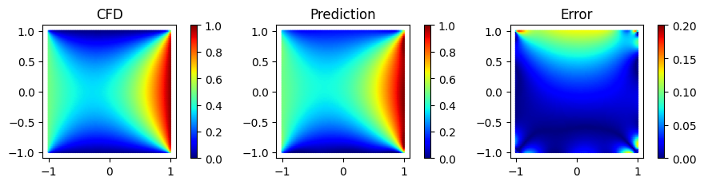

```python
# for epoch in range(epochs):

#     ## PDE loss
#     pde_term = PDE(model, Y_domain)
#     loss_pde = torch.mean(pde_term**2)

#     ## BC loss
#     T_bottom = BC_bottom(model, Y_bottom)
#     T_right = BC_right(model, Y_right)
#     T_left = BC_left(model, Y_left)

#     loss_bc = torch.mean(T_bottom**2) + torch.mean(T_right**2) + torch.mean(T_left**2)

#     ## Data loss
#     T_obs = model(Y_obs)
#     loss_data = torch.mean((T_obs - gt_obs)**2)

#     ## Prior Knowledge
#     T_top = model(Y_top)
#     loss_prior = torch.mean((T_top - torch.mean(T_top))**2)

#     loss = loss_pde + loss_bc + loss_data + loss_prior

#     optimizer.zero_grad()
#     loss.backward()
#     optimizer.step()

#     if epoch % 1000 == 0:
#         print('EPOCH : %6d/%6d| Loss : %5.4f | Loss_PDE : %5.4f | Loss_BC : %5.4f | Loss_DATA : %5.4f | Loss_PRIOR : %5.4f' \
#                 %(epoch, epochs - 1, loss.item(), loss_pde.item(), loss_bc.item(), loss_data.item(), loss_prior.item()))
#         PLOT(model, Y_domain)
```

```python
# torch.save(model, 'lab4_w_prior.pt')
# print("Model successfully saved as lab4_w_prior.pt")
```

```
Model successfully saved as lab4_w_prior.pt
```

**Load the model parameters**

- [lab4_w_prior.pt](https://drive.google.com/file/d/1OQPMZEBvz3d_MeodYeiYJBVCrmwrgLms/view?usp=sharing)

```python
!gdown 1OQPMZEBvz3d_MeodYeiYJBVCrmwrgLms -O /content/lab4_w_prior.pt
```

```
Downloading...
From: https://drive.google.com/uc?id=1OQPMZEBvz3d_MeodYeiYJBVCrmwrgLms
To: /content/lab4_w_prior.pt
100% 800k/800k [00:00<00:00, 128MB/s]
```

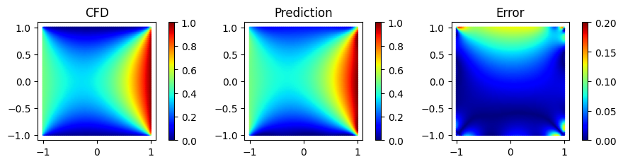

```python
model_w_prior = torch.load('/content/lab4_w_prior.pt', map_location = device, weights_only = False)
PLOT(model_w_prior, Y_domain)
```

**Result**

It is clearly observed that the final prediction is the most accurate among the three different scenarios, which was predictable from an information argument alone and did not require running anything. Two conclusions follow.

The first concerns the PINN framework itself. We have now seen it absorb three different kinds of knowledge into a single objective function: a governing equation, a set of measurements, and a qualitative structural fact. All three entered in the same way, as a non-negative term that vanishes when the knowledge is respected, and all three were minimized by the same optimizer in the same loop. That uniformity is the framework's real strength, more than any individual result in this notebook.

The second is a strategy for engineering problems generally. When addressing a complex engineering challenge, begin by asking what data is available, and then, rather than stopping there, ask what *else* is known: governing equations, boundary conditions, conservation laws, symmetries, monotonicity, bounds, results from a simplified analysis, or the engineer's judgement that a certain surface must be at uniform temperature. Each such item is a constraint, each constraint is a term, and each term reduces the size of the space in which the answer is being sought. Data is one source of information among several, and in engineering it is frequently the scarcest.

## 5.5. What the Three Labs Showed

To evaluate the models' performance more precisely, we plot the predicted temperature along the top boundary itself. This gives a direct comparison against the ground truth and shows how well each model captured the missing boundary condition.

The ground truth appears in the plot as a line of zeros: the true temperature along the top edge is uniformly zero. Note that this is consistent with the prior knowledge used in Section 5.4, which asserted uniformity without naming the value, and that the value itself was never supplied to any of the three models.

Predict the three curves before looking. The model without data has no information about the edge at all, so its profile can be anything and should be furthest from zero. The model with data has nine interior constraints and should be closer but uneven along the edge, since nothing forces it to be flat. The model with the prior should be nearly flat by construction, at whichever constant the sensors imply.

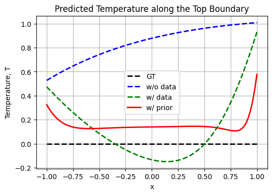

```python
model_wo_data = torch.load('/content/lab4_wo_data.pt', map_location = device, weights_only = False)
model_w_data = torch.load('/content/lab4_w_data.pt', map_location = device, weights_only = False)
model_w_prior = torch.load('/content/lab4_w_prior.pt', map_location = device, weights_only = False)

x_top = Y_top[:, 0].cpu().numpy()

T_wo_data = model_wo_data(Y_top).detach().cpu().numpy().flatten()
T_w_data = model_w_data(Y_top).detach().cpu().numpy().flatten()
T_w_prior = model_w_prior(Y_top).detach().cpu().numpy().flatten()

plt.figure(figsize = (6, 4))
plt.plot(x_top, np.zeros_like(x_top), c = 'k', linestyle = '--', linewidth = 2, label = 'GT')
plt.plot(x_top, T_wo_data, c = 'b', linestyle = '--', linewidth = 2, label = 'w/o data')
plt.plot(x_top, T_w_data, c = 'g', linestyle = '--', linewidth = 2, label = 'w/ data')
plt.plot(x_top, T_w_prior, c = 'r', linewidth = 2, label = 'w/ prior')
plt.xlabel('x')
plt.ylabel('Temperature, T')
plt.title('Predicted Temperature along the Top Boundary')
plt.legend()
plt.grid(True)
plt.show()
```

The plot confirms the ordering, and the shapes of the curves are as informative as their distances from the truth. The unconstrained model wanders; the data-only model is pulled towards the truth in the middle of the edge, where the sensors have most influence, and drifts near the corners where they have least; the model with the prior is flat, because flatness is what the variance penalty enforces, and sits close to zero, because that is where nine interior temperatures place the constant.

One last observation to close the section. The improvement from the second model to the third came from no new measurements whatsoever. It came from writing down something the engineer already knew. That is a good note on which to leave inverse problems.

# Summary

**Looking ahead.** Every loss in this notebook was a sum of terms whose weights were chosen by hand, and the results depended on those choices. How to set them — and how to avoid having to set them at all — is the subject of **Regularization, MAP Estimation, and Loss Weighting**.